# Consumer Reviews of Amazon Products

#### Dataset Source:[Kaggle Source: Consumer Reviews of Amazon Products](https://www.kaggle.com/datafiniti/consumer-reviews-of-amazon-products?select=1429_1.csv)

#### This dataset consists of reviews of Amazon Products.

## 1-Read the data

```python
import pandas as pd
df = pd.read_csv('1429_1.csv', encoding='utf-8', header=0)
df.head()
```

|  | id | name | asins | brand | categories | keys | manufacturer | reviews.date | reviews.dateAdded | reviews.dateSeen | ... | reviews.doRecommend | reviews.id | reviews.numHelpful | reviews.rating | reviews.sourceURLs | reviews.text | reviews.title | reviews.userCity | reviews.userProvince | reviews.username |
| --- | --- | --- | --- | --- | --- | --- | --- | --- | --- | --- | --- | --- | --- | --- | --- | --- | --- | --- | --- | --- | --- |
| 0 | AV1YE_muvKc47QAVgpwE | NaN | B00U3FPN4U | Amazon Fire Tv | Back To College,College Electronics,College Tv... | 848719057492,amazonfiretv/51454342,amazonfiret... | Amazon | 2016-10-14T00:00:00.000Z | 2017-09-20T05:35:53Z | 2017-08-25T22:05:00.301Z,2017-08-19T09:35:32.6... | ... | True | NaN | 0.0 | 5.0 | http://reviews.bestbuy.com/3545/4370400/review... | - A MUST for Amazon Prime subscribers - lots o... | Great streaming device!! | NaN | NaN | John |
| 1 | AV1YE_muvKc47QAVgpwE | NaN | B00U3FPN4U | Amazon Fire Tv | Back To College,College Electronics,College Tv... | 848719057492,amazonfiretv/51454342,amazonfiret... | Amazon | 2016-09-21T00:00:00.000Z | 2017-09-20T05:35:53Z | 2017-08-25T22:05:25.430Z,2017-08-19T09:35:39.0... | ... | True | NaN | 0.0 | 5.0 | http://reviews.bestbuy.com/3545/4370400/review... | . Works great. Super fast loading opposed to t... | noticeably faster than the 40$ firestick! | NaN | NaN | MrChrome |
| 2 | AVphgVaX1cnluZ0-DR74 | Fire Tablet, 7 Display, Wi-Fi, 8 GB - Includes... | B018Y229OU | Amazon | Fire Tablets,Tablets,Computers & Tablets,All T... | firetablet7displaywifi8gbincludesspecialoffers... | Amazon | 2016-12-27T00:00:00.000Z | 2017-05-21T01:23:26Z | 2017-04-30T00:09:00.000Z,2017-06-07T08:17:00.000Z | ... | False | NaN | 0.0 | 1.0 | http://reviews.bestbuy.com/3545/5025800/review... | .. I bought four of these tablets two of them ... | problems from the start | NaN | NaN | kina |
| 3 | AV1YnRtnglJLPUi8IJmV | Amazon Kindle Paperwhite - eBook reader - 4 GB... | B00OQVZDJM | Amazon | Walmart for Business,Office Electronics,Tablet... | amazon/b00oqvzdjm,848719056099,amazonkindlepap... | Amazon | 2017-07-14T00:00:00.000Z | 2017-09-05T22:09:30Z | 2017-08-31T22:33:07.174Z,2017-08-02T19:54:04.5... | ... | True | NaN | 0.0 | 5.0 | http://reviews.bestbuy.com/3545/9439005/review... | ... and anywhere else! I love it. For the firs... | Perfect for poolside | NaN | NaN | txpuckma |
| 4 | AVpfl8cLLJeJML43AE3S | Echo (White),,,\r\nEcho (White),,, | B00L9EPT8O,B01E6AO69U | Amazon | Stereos,Remote Controls,Amazon Echo,Audio Dock... | echowhite/263039693056,echowhite/152558276095,... | Amazon | 2017-07-10T00:00:00.000Z | NaN | 2017-09-28T00:00:00Z,2017-09-08T00:00:00Z,2017... | ... | True | NaN | 0.0 | 5.0 | http://reviews.bestbuy.com/3545/5588528/review... | ... in confined spaces. The kids room does wor... | Great Sound | NaN | NaN | Rolando |

5 rows × 21 columns

#### This dataset doesn't have a target column. We create one artificially by assuming reviews with score less than 3 will be negative and the rest is positive. **You DON'T need to do this with your final project as it will already have a target column.**

```python
def polarity(x):
    if x < 3:
        return 0
    else:
        return 1
df["reviews.rating"] = df["reviews.rating"].map(polarity) #Map all the scores as the function polarity i.e. positive or negative
df.head()
```

|  | id | name | asins | brand | categories | keys | manufacturer | reviews.date | reviews.dateAdded | reviews.dateSeen | ... | reviews.doRecommend | reviews.id | reviews.numHelpful | reviews.rating | reviews.sourceURLs | reviews.text | reviews.title | reviews.userCity | reviews.userProvince | reviews.username |
| --- | --- | --- | --- | --- | --- | --- | --- | --- | --- | --- | --- | --- | --- | --- | --- | --- | --- | --- | --- | --- | --- |
| 0 | AV1YE_muvKc47QAVgpwE | NaN | B00U3FPN4U | Amazon Fire Tv | Back To College,College Electronics,College Tv... | 848719057492,amazonfiretv/51454342,amazonfiret... | Amazon | 2016-10-14T00:00:00.000Z | 2017-09-20T05:35:53Z | 2017-08-25T22:05:00.301Z,2017-08-19T09:35:32.6... | ... | True | NaN | 0.0 | 1 | http://reviews.bestbuy.com/3545/4370400/review... | - A MUST for Amazon Prime subscribers - lots o... | Great streaming device!! | NaN | NaN | John |
| 1 | AV1YE_muvKc47QAVgpwE | NaN | B00U3FPN4U | Amazon Fire Tv | Back To College,College Electronics,College Tv... | 848719057492,amazonfiretv/51454342,amazonfiret... | Amazon | 2016-09-21T00:00:00.000Z | 2017-09-20T05:35:53Z | 2017-08-25T22:05:25.430Z,2017-08-19T09:35:39.0... | ... | True | NaN | 0.0 | 1 | http://reviews.bestbuy.com/3545/4370400/review... | . Works great. Super fast loading opposed to t... | noticeably faster than the 40$ firestick! | NaN | NaN | MrChrome |
| 2 | AVphgVaX1cnluZ0-DR74 | Fire Tablet, 7 Display, Wi-Fi, 8 GB - Includes... | B018Y229OU | Amazon | Fire Tablets,Tablets,Computers & Tablets,All T... | firetablet7displaywifi8gbincludesspecialoffers... | Amazon | 2016-12-27T00:00:00.000Z | 2017-05-21T01:23:26Z | 2017-04-30T00:09:00.000Z,2017-06-07T08:17:00.000Z | ... | False | NaN | 0.0 | 0 | http://reviews.bestbuy.com/3545/5025800/review... | .. I bought four of these tablets two of them ... | problems from the start | NaN | NaN | kina |
| 3 | AV1YnRtnglJLPUi8IJmV | Amazon Kindle Paperwhite - eBook reader - 4 GB... | B00OQVZDJM | Amazon | Walmart for Business,Office Electronics,Tablet... | amazon/b00oqvzdjm,848719056099,amazonkindlepap... | Amazon | 2017-07-14T00:00:00.000Z | 2017-09-05T22:09:30Z | 2017-08-31T22:33:07.174Z,2017-08-02T19:54:04.5... | ... | True | NaN | 0.0 | 1 | http://reviews.bestbuy.com/3545/9439005/review... | ... and anywhere else! I love it. For the firs... | Perfect for poolside | NaN | NaN | txpuckma |
| 4 | AVpfl8cLLJeJML43AE3S | Echo (White),,,\r\nEcho (White),,, | B00L9EPT8O,B01E6AO69U | Amazon | Stereos,Remote Controls,Amazon Echo,Audio Dock... | echowhite/263039693056,echowhite/152558276095,... | Amazon | 2017-07-10T00:00:00.000Z | NaN | 2017-09-28T00:00:00Z,2017-09-08T00:00:00Z,2017... | ... | True | NaN | 0.0 | 1 | http://reviews.bestbuy.com/3545/5588528/review... | ... in confined spaces. The kids room does wor... | Great Sound | NaN | NaN | Rolando |

5 rows × 21 columns

### Data class imbalance:

It happens when one of the classes dominates the other class(es). Supervised machine learning models learn through examples (training data). It is important to have a good representation of data before training our model. Let's go through an example here.

Let's plot our data using the new score values: Positive and Negative.

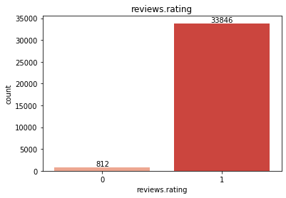

```python
import matplotlib.pyplot as plt
import seaborn as sb

plt.figure()
ax = sb.countplot(x=df["reviews.rating"], y = None, palette = "Reds")
for p in ax.patches:
    x=p.get_bbox().get_points()[:,0]
    y=p.get_bbox().get_points()[1,1]
    ax.annotate('{:.0f}'.format(y), (x.mean(), y), ha='center', va='bottom')
plt.title('reviews.rating')
plt.show()
```

### Upsampling the Negative class:

**Important note:** For upsampling, we have to use **replace=True**

```python
from sklearn.utils import shuffle, resample

# Let's copy our dataframe so that we can use it clean for the upsampling example later.
df2 = df[["reviews.text","reviews.rating"]]

# Let's seperate our data into two based on the Score (True of False).
df_negative = df2[df2["reviews.rating"] == 0]
df_positive = df2[df2["reviews.rating"] == 1]

print("Number of records before upsampling: ")
print("1:", len(df_positive), "0:", len(df_negative))
```

```
Number of records before upsampling:
1: 33846 0: 812
```

```python
# Let's use the resample function for upsampling.
df_negative = resample(df_negative, replace=True, n_samples=len(df_positive))

# Let's put the separated data frames together.
df2 = pd.concat([df_negative, df_positive], axis=0)

# Let's shuffle the data
df2 = shuffle(df2)

print("Number of records after upsampling: ")
print("Positive:", len(df2[df2["reviews.rating"] == 1]), "Negative:", len(df2[df2["reviews.rating"] == 0]))
```

```
Number of records after upsampling:
Positive: 33846 Negative: 33846
```

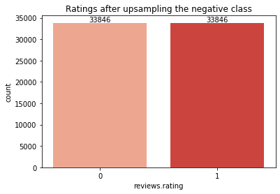

```python
import matplotlib.pyplot as plt
import seaborn as sb

plt.figure()
ax = sb.countplot(x=df2["reviews.rating"], y = None, palette = "Reds")
for p in ax.patches:
    x=p.get_bbox().get_points()[:,0]
    y=p.get_bbox().get_points()[1,1]
    ax.annotate('{:.0f}'.format(y), (x.mean(), y), ha='center', va='bottom')
plt.title('Ratings after upsampling the negative class')
plt.show()
```

```python
df2.to_csv('check.csv', index=False)
```

## 2-Exploratory Analysis and Preprocessing

```python
# Let's see how many nan values in our data frame
print(df2.isna().sum())
```

```
reviews.text      0
reviews.rating    0
dtype: int64
```

Let's split our data into training and validation subsets.

```python
from sklearn.model_selection import train_test_split

X_train, X_val, y_train, y_val = train_test_split(df2[["reviews.text"]], df2["reviews.rating"].values, test_size=0.15, shuffle=True)
```

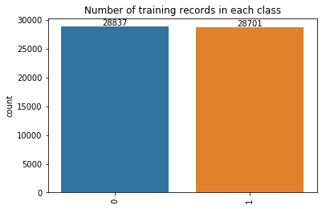

```python
import matplotlib.pyplot as plt
import seaborn as sb

plt.figure()
ax = sb.countplot(x=y_train, y = None)
for p in ax.patches:
    x=p.get_bbox().get_points()[:,0]
    y=p.get_bbox().get_points()[1,1]
    ax.annotate('{:.0f}'.format(y), (x.mean(), y), ha='center', va='bottom')
plt.xticks(rotation=90)
plt.title('Number of training records in each class')
plt.show()
```

Let's pre-process the data. We will remove stopwords and apply stemming

```python
import nltk
from nltk.corpus import stopwords
from nltk.stem import SnowballStemmer
from nltk.tokenize import word_tokenize

nltk.download('punkt', download_dir='/tmp/')
nltk.download('stopwords', download_dir='/tmp/')
nltk.data.path.append("tmp")

snow = SnowballStemmer('english')
stop = stopwords.words('english')

#excluding some useful words from stop words list
excluding = ['against','not','don', "don't",'ain', 'aren', "aren't", 'couldn', "couldn't", 'didn', "didn't",
             'doesn', "doesn't", 'hadn', "hadn't", 'hasn', "hasn't", 'haven', "haven't", 'isn', "isn't",
             'mightn', "mightn't", 'mustn', "mustn't", 'needn', "needn't",'shouldn', "shouldn't", 'wasn',
            "wasn't", 'weren', "weren't", 'won', "won't", 'wouldn', "wouldn't"]

stop_words = [words for words in stop if words not in excluding]

def process_text(texts):
    final_text_list=[]
    for sent in texts:
        filtered_sentence=[]
        sent = sent.lower()
        for w in word_tokenize(sent):
            # Check if it is not numeric and its length>2 and not in stop words
            if(not w.isnumeric()) and (len(w)>2) and (w not in stop_words):
                # Stem and add to filtered list
                filtered_sentence.append(snow.stem(w))
        str1 = " ".join(filtered_sentence) #final string of cleaned words

        final_text_list.append(str1)
    return final_text_list
```

Let's call the function below.

```python
print("Pre-process training dataset")
X_train_text_processed = process_text(X_train["reviews.text"].values)

print("Pre-process validation dataset")
X_val_text_processed = process_text(X_val["reviews.text"].values)
```

```
Pre-process training dataset
Pre-process validation dataset
```

## 4-Vectorization (Feature Extraction)

#### Naive Bayes algorithm uses CountVectorizer(), so we will vectorize our text data using count vectorizer. Let's also experiment with max_features and ngram parameters here.

#### Realize that we called the **fit() function** only once on training data. This is because we want to test our method on unseen words as well.

```python
from sklearn.feature_extraction.text import CountVectorizer

#Text -> Uni gram count Vectors
tf_vectorizer = CountVectorizer(max_features=9500, ngram_range=(1, 2))
tf_vectorizer.fit(X_train_text_processed)
X_train = tf_vectorizer.transform(X_train_text_processed)
print("Training Data Size: ", X_train.shape)

X_val = tf_vectorizer.transform(X_val_text_processed)
print("Validation Data Size: ", X_val.shape)
```

```
Training Data Size:  (57538, 9500)
Validation Data Size:  (10154, 9500)
```

## 5-Naive Bayes

Naive Bayes is fast and simple so useful as a baseline to judge other algorithms against.

```python
#Training the model and Testing Accuracy on Validation data
from sklearn.metrics import classification_report
from sklearn.naive_bayes import MultinomialNB

nb = MultinomialNB()
nb.fit(X_train.toarray(), y_train)

y_val_pred = nb.predict(X_val.toarray())

print(classification_report(y_val, y_val_pred))
```

```
              precision    recall  f1-score   support

           0       0.95      0.90      0.92      5009
           1       0.91      0.96      0.93      5145

    accuracy                           0.93     10154
   macro avg       0.93      0.93      0.93     10154
weighted avg       0.93      0.93      0.93     10154
```

## 6-Confusion matrix

#### Confusion matrix is a good resource for calculating all the metrics we got with the classification_report in Section 5.

```python
from sklearn.metrics import confusion_matrix
confusion_matrix(y_val, y_val_pred)
```

```
array([[4496,  513],
       [ 222, 4923]])
```